# The impact of El Niño on the Species Composition of Genera *Amphiprion* and *Lutjanus* in Australia

R12241209 Lin, Ting-Chang, R12241202 Chang, Hsin-Yu, R12241206 Liu, Li-Hsuan

2023-12-08

Introduction

In this project, we manipulated the *‘IMOS - National Reef Monitoring Network Sub-Facility - Global reef fish abundance and biomass’* data set from Systematic global assessment of reef fish communities by the Reef Life Survey program. After manipulating the data, we observed that most of it was collected around Australia. Thus, we decided to restrict our survey area in Australia. We identified two genera, *Amphiprion* and *Hypoplectrodes*, which are distributed in the northern and southern coastal areas of Australia, respectively. We chose to compare the species composition of *Amphiprion* and *Hypoplectrodes* during El Niño years and normal years to assess if El Niño has different impacts on tropical and subtropical genera.

Yet, after calculating the number of individuals of *Hypoplectrodes* in different years, we discovered a dominant species, *Hypoplectrodes maccullochi*, within the genus *Hypoplectrodes* around Australia. Recognizing that the test of homogeneity would be inefficient in this case, we decided to shift our focus and compare the species composition of *Amphiprion* and *Lutjanus*. Both genera have sufficient survey data in this dataset.

•El Niño

During El Niño years, the weakening of trade winds causes the North Pacific warm pool to shift toward the east side. As a result, the surface seawater temperature (SST) around Australia will be lower than normal. We expect this difference in SST will have impacts on species composition of tropical and subtropical genera to different extent. (https://geographical.co.uk/science-environment/geo-explainer-el-nino)

•The optimal temperature for *Amphiprion*, *Hypoplectrodes* and *Lutjanus*

*Amphiprion*: For the well-researched *A. ocellaris*, the optimal temperature is said to be around 29℃ or 30℃ (Soman et al., 2021; Velasco et al., 2019). *Hypoplectrodes*: According to FishBase (https://www.fishbase.se/search.php), the dominant species in Australia, H. maccullochi, has a preferred temperature range of 17.3℃ to 24.7℃. *Lutjanus*: There are abundant species in this genus, so we can only generalize their preferred temperature range to be between 18℃ and 29℃.

•Hypothesis

H0: The species composition of *Amphiprion* and *Lutjanus* during El Niño years and normal years shows no differences.

H1: The species composition of *Amphiprion* and *Lutjanus* during El Niño years and normal years shows differences.

Methods

Check the working directory.

```r
getwd()
```

```
## [1] "C:/Users/IRIS/Documents/R_class/Rclass2023/final report"
```

Library all packages we would use.

```r
library(readxl)
library(data.table)
library(leaflet)
library(rgbif)
library(tidyverse)
library(data.table)
library(dplyr)
library(sf)
library(tidyr)
library(leaflet.extras)
library(ggplot2)
library(ggeasy)
```

Check the data and make it more clear and visual.

```r
#read the data file
Data <- fread("IMOS.csv", fill=TRUE, na.strings = c("", NA))

#change the format to data table
Data_dt <- as.data.table(Data)

#deleted all the unimportant information
Data_dt <-Data_dt[-c(1:71), ]

#make every colon with right name
colnames(Data_dt) <- as.character(Data_dt[1, ])
Data_dt <-Data_dt[-c(1), ]
```

We chose Australia as the place we want to focus on.

Make a subset of survey data that is from Australia.

```r
#select all data from Australia
Aus <- Data_dt$country=="Australia"
Australia <- Data_dt[Aus,]

#separate species name and time
#On the name, we want to separate the genera and specific epithets into two columns
#On the time we want to separate by year, month and day into three columns
Australia<-separate(Australia, reporting_name, c("Genus", "name"), " ")
Australia<- separate(Australia, survey_date, c("Year", "Month", "Day"), "-")

#change longitude, latitude and species total number as numeric format
Australia$longitude <- as.numeric(Australia$longitude)
Australia$latitude <- as.numeric(Australia$latitude)
Australia$total <-as.numeric(Australia$total)

#change format to data table
Australia<- as.data.table(Australia)
```

As we mentioned in the introduction, we chose three genera to test our hypothesis.

Make subset of three genera.

```r
#Amphiprion
amp <- Australia$Genus=="Amphiprion"
Amphiprion<- Australia[amp,]

#Hypoplectrodes
hyp <- Australia$Genus=="Hypoplectrodes"
Hypoplectrodes<- Australia[hyp,]

#Lutjanidae
lut <- Australia$Genus=="Lutjanus"
Lutjanus<- Australia[lut,]
```

Choose the data from 2016(El Niño year) and 2019(normal year), and make them become an independent data table.

```r
#2016

#Amphiprion
Amp_2016 <- Amphiprion$Year=="2016"
Amphiprion_2016 <- Amphiprion[Amp_2016,]

#Hypoplectrodes
Hyp_2016 <- Hypoplectrodes$Year=="2016"
Hypoplectrodes_2016 <- Hypoplectrodes[Hyp_2016,]

#Lutjanidae
Lut_2016 <- Lutjanus$Year=="2016"
Lutjanus_2016 <- Lutjanus[Lut_2016,]


#2019
#high temperature

#Amphiprion
Amp_2019 <- Amphiprion$Year=="2019"
Amphiprion_2019 <- Amphiprion[Amp_2019,]

#Amphiprion
Hyp_2019 <- Hypoplectrodes$Year=="2019"
Hypoplectrodes_2019 <- Hypoplectrodes[Hyp_2019,]

#Amphiprion
Lut_2019 <- Lutjanus$Year=="2019"
Lutjanus_2019 <- Lutjanus[Lut_2019,]
```

Before we started to analyze the data, we made a map to check the distribution of these three genera.

Distribution of three genera in 2016 and 2019.

```r
Distribution <- leaflet() %>%
  addTiles() %>%
  addMarkers(data=Amphiprion_2016, group= "Amphiprion_2016", ~longitude, ~latitude)%>%
  addMarkers(data=Amphiprion_2019, group= "Amphiprion_2019", ~longitude, ~latitude)%>%
  addMarkers(data=Hypoplectrodes_2016, group= "Hypoplectrodes_2016", ~longitude, ~latitude)%>%
  addMarkers(data=Hypoplectrodes_2019, group= "Hypoplectrodes_2019", ~longitude, ~latitude)%>%
  addMarkers(data=Lutjanus_2016, group= "Lutjanus_2016", ~longitude, ~latitude)%>%
  addMarkers(data=Lutjanus_2019, group= "Lutjanus_2019", ~longitude, ~latitude)%>%
  addLayersControl(baseGroups = c("Amphiprion_2016", "Amphiprion_2019","Hypoplectrodes_2016", "Hypoplectrodes_2019","Lutjanus_2016", "Lutjanus_2019"  ),
    options = layersControlOptions(collapsed = FALSE)
  )

Distribution
```

[interactive chart not shown]

Step by step to analysis our data by each genus.

First is *Amphiprion*.

Check how many species have been observed and their observation numbers in 2016 and 2019.

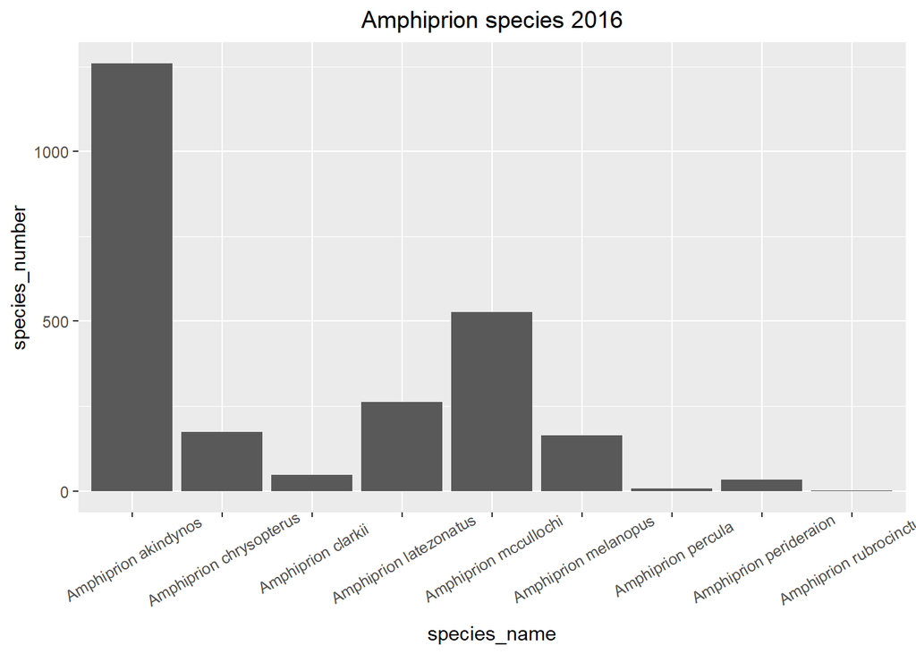

```r
#2016

#Create a new column named number to sum all the observation numbers by their names.
Amphiprion_2016 <- Amphiprion_2016[, number := sum(total), by= species_name]

#Make another table that only contains species name, family and observation numbers
Amphiprion_2016_species <- Amphiprion_2016[, unique(number), by =c("species_name", "family")]

#change the column name
Amphiprion_2016_species<- dplyr::rename(Amphiprion_2016_species, species_number=V1)

#Use a bar plot to see the observation numbers for each species.
#This plot represents every species observation numbers for Amphiprion in 2016.
ggplot(Amphiprion_2016_species, aes(x= species_name, y= species_number)) +
  geom_bar(stat = "identity")+
  ggtitle("Amphiprion species 2016")+
  ggeasy::easy_center_title()+
  theme(axis.text.x = element_text(vjust = 0.65, angle = 30))
```

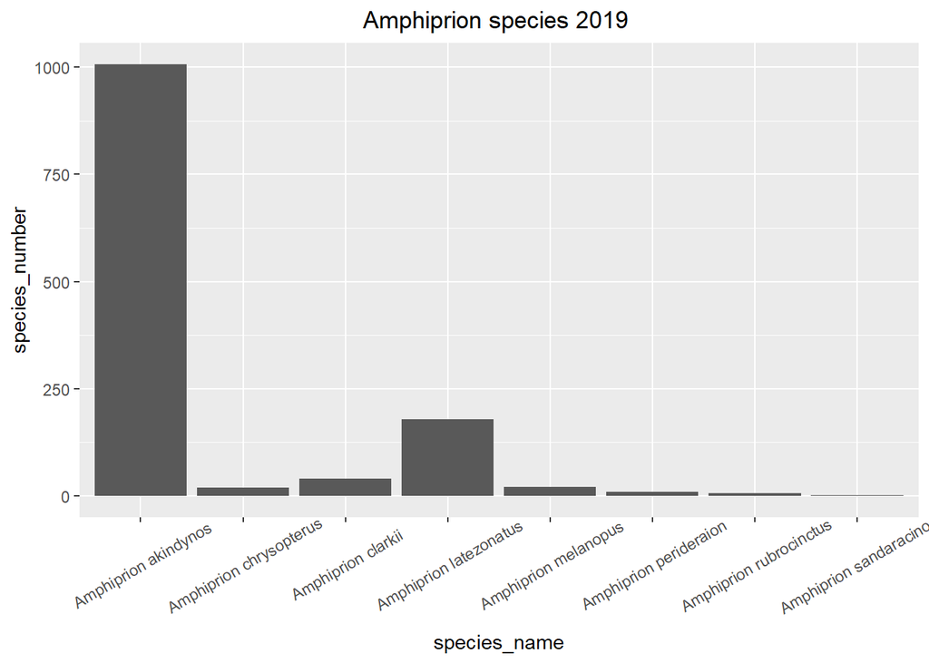

```r
#2019
#Use the same method as above to create the bar plot of every species observation numbers of Amphiprion in 2019.
Amphiprion_2019 <- Amphiprion_2019[, number := sum(total), by= species_name]
Amphiprion_2019_species <- Amphiprion_2019[, unique(number), by =c("species_name", "family")]
Amphiprion_2019_species<- dplyr::rename(Amphiprion_2019_species, species_number=V1)

ggplot(Amphiprion_2019_species, aes(x= species_name, y= species_number)) +
  geom_bar(stat = "identity")+
  ggtitle("Amphiprion species 2019 ")+
  ggeasy::easy_center_title()+
  theme(axis.text.x = element_text(vjust = 0.65, angle = 30))
```

Compare species between 2016 and 2019, and choose those species that were both observed in 2016 and 2019. And make a bar plot of their observation numbers.

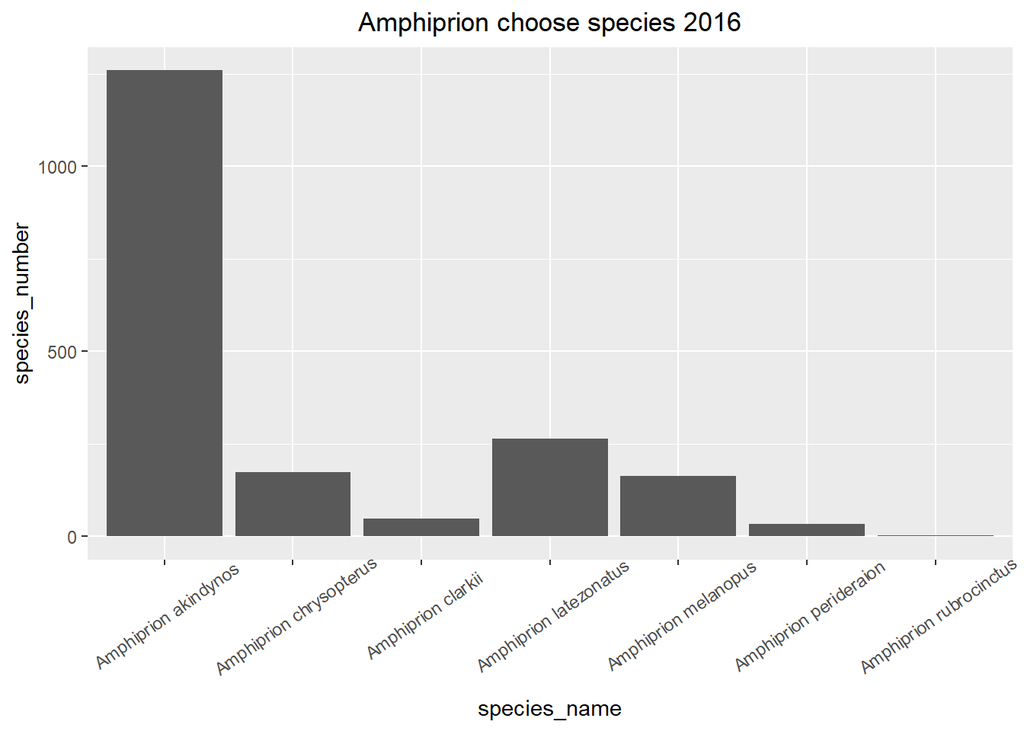

```r
#2016

#Deleted those species not observed in 2016
Amphiprion_2016_species_7 <- Amphiprion_2016_species[-c(1,9),]

#bar plot of 2016
ggplot(Amphiprion_2016_species_7, aes(x= species_name, y= species_number)) +
  geom_bar(stat = "identity")+
  ggtitle("Amphiprion choose species 2016")+
  ggeasy::easy_center_title()+
  theme(axis.text.x = element_text(vjust = 0.65, angle = 35))
```

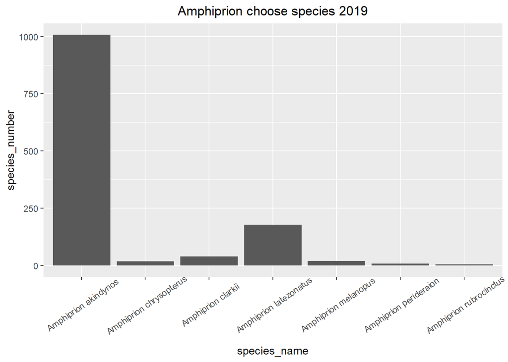

```r
Amphiprion_2016_species_7[, year:= 2016, by ="family"]

#Deleted those species not in 2019
Amphiprion_2019_species_7 <- Amphiprion_2019_species[-4,]

#bar plot of 2019
ggplot(Amphiprion_2019_species_7, aes(x= species_name, y= species_number)) +
  geom_bar(stat = "identity")+
  ggtitle("Amphiprion choose species 2019")+
  ggeasy::easy_center_title()+
  theme(axis.text.x = element_text(vjust = 0.65, angle = 35))
```

```r
Amphiprion_2019_species_7[, year:= 2019, by ="family"]
```

However, we thought that used direct observation numbers to test if there was a significant change between these two years was too subjective. Then we used the observation number divided by the survey number to calculate each species’ density.

```r
Amphiprion_2019_2016 <- rbind(Amphiprion_2019_species_7, Amphiprion_2016_species_7)

#species number/ survey number= density
Amphiprion_2019_2016[year=="2019", density:= (species_number/nrow(Amphiprion_2019))]
Amphiprion_2019_2016[year=="2016", density:= (species_number/nrow(Amphiprion_2016))]

#The value of density is a little bit low, so we use log for transformation.
Amphiprion_2019_2016[,log:= log(density)]
```

Use two sample t-test and Fligner-Killeen test to test if species composition are significant different between 2016 and 2019.

```r
#Two sample t-test
t.test(Amphiprion_2019_2016$density~Amphiprion_2019_2016$year)
```

```
##
##  Welch Two Sample t-test
##
## data:  Amphiprion_2019_2016$density by Amphiprion_2019_2016$year
## t = -0.7199, df = 7.3204, p-value = 0.4939
## alternative hypothesis: true difference in means between group 2016 and group 2019 is not equal to 0
## 95 percent confidence interval:
##  -3.459913  1.833906
## sample estimates:
## mean in group 2016 mean in group 2019
##          0.5924908          1.4054945
```

```r
#Fligner-Killeen test
fligner.test (Amphiprion_2019_2016$density~Amphiprion_2019_2016$year)
```

```
##
##  Fligner-Killeen test of homogeneity of variances
##
## data:  Amphiprion_2019_2016$density by Amphiprion_2019_2016$year
## Fligner-Killeen:med chi-squared = 0.076631, df = 1, p-value = 0.7819
```

Both p-value are higher than 0.05, so reject our H1 hypothesis.

Next we make another bar plot to see the density difference between 2016 to 2019 on different species.

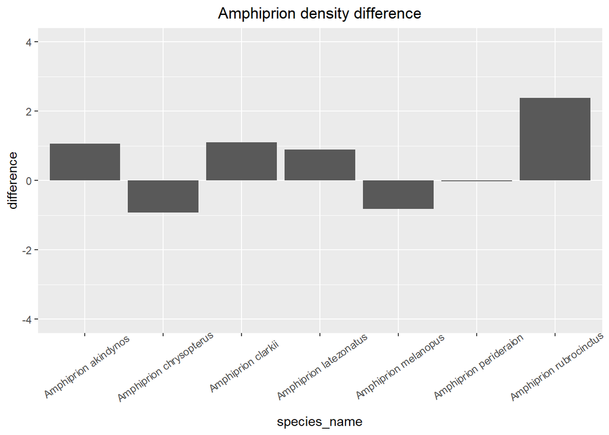

```r
#Change the column name
Amphiprion_2019_2016_19<-Amphiprion_2019_2016[1:7,]
colnames(Amphiprion_2019_2016_19)[3:6]<-c("species_number_2019", "year_2019", "density_2019", "log_2019")
Amphiprion_2019_2016_16<-Amphiprion_2019_2016[8:14,]
colnames(Amphiprion_2019_2016_16)[3:6]<-c("species_number_2016", "year_2016", "density_2016", "log_2016")

#Combined two data table of different years
Amphiprion_2019_2016_new <-merge(Amphiprion_2019_2016_19, Amphiprion_2019_2016_16)

#Calculate density difference of two years and make it to a new column
Amphiprion_2019_2016_new[, difference:=(log_2019-log_2016)]

#bar plot
ggplot(Amphiprion_2019_2016_new, aes(x= species_name, y= difference)) +
  geom_bar(stat = "identity")+
  scale_y_continuous(limits = c(-4,4))+
  ggtitle("Amphiprion density difference")+
  ggeasy::easy_center_title()+
  theme(axis.text.x = element_text(vjust = 0.65, angle = 35))
```

Second genus is *Hypoplectrodes*.

Use the same steps as above.

Check how many species have been observed and their observation numbers in 2016 and 2019.

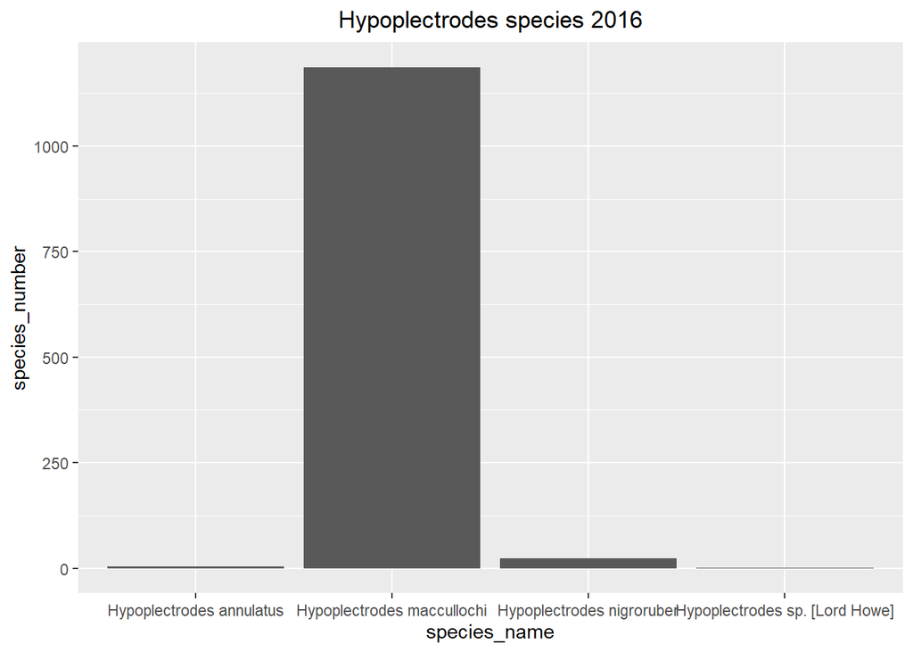

```r
#2016
Hypoplectrodes_2016 <-as.data.table(Hypoplectrodes_2016)
Hypoplectrodes_2016<- Hypoplectrodes_2016[, number := sum(total), by=species_name]
Hypoplectrodes_2016_species <- Hypoplectrodes_2016[, unique(number), by =c("species_name", "family")]
Hypoplectrodes_2016_species<- dplyr::rename(Hypoplectrodes_2016_species, species_number=V1)

ggplot(Hypoplectrodes_2016_species, aes(x= species_name, y= species_number)) +
  geom_bar(stat = "identity")+
  ggtitle("Hypoplectrodes species 2016")+
  ggeasy::easy_center_title()+
  theme(axis.text.x = element_text(vjust = 0.65))
```

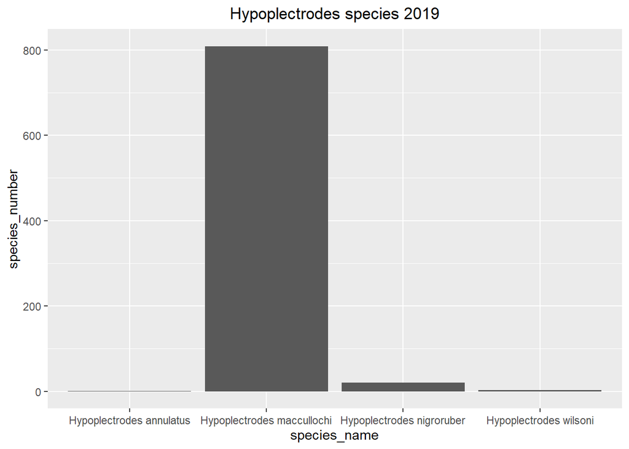

```r
#2019
Hypoplectrodes_2019 <-as.data.table(Hypoplectrodes_2019)
Hypoplectrodes_2019<- Hypoplectrodes_2019[, number := sum(total), by=species_name]
Hypoplectrodes_2019_species <- Hypoplectrodes_2019[, unique(number), by =c("species_name", "family")]
Hypoplectrodes_2019_species<- dplyr::rename(Hypoplectrodes_2019_species, species_number=V1)

ggplot(Hypoplectrodes_2019_species, aes(x= species_name, y= species_number)) +
  geom_bar(stat = "identity")+
  ggtitle("Hypoplectrodes species 2019")+
  ggeasy::easy_center_title()+
  theme(axis.text.x = element_text(vjust = 0.65))
```

We found that in the genus *Hypoplectrodes*, there was just one dominant species in 2016 and 2019.So it was hard to test the difference between two years. And then we changed the target genus from *Hypoplectrodes* to *Lutjanus*.

Third genus is *Lutjanus*

Also we use the same steps as above.

First is to check how many species have been observed and their observation numbers in 2016 and 2019.

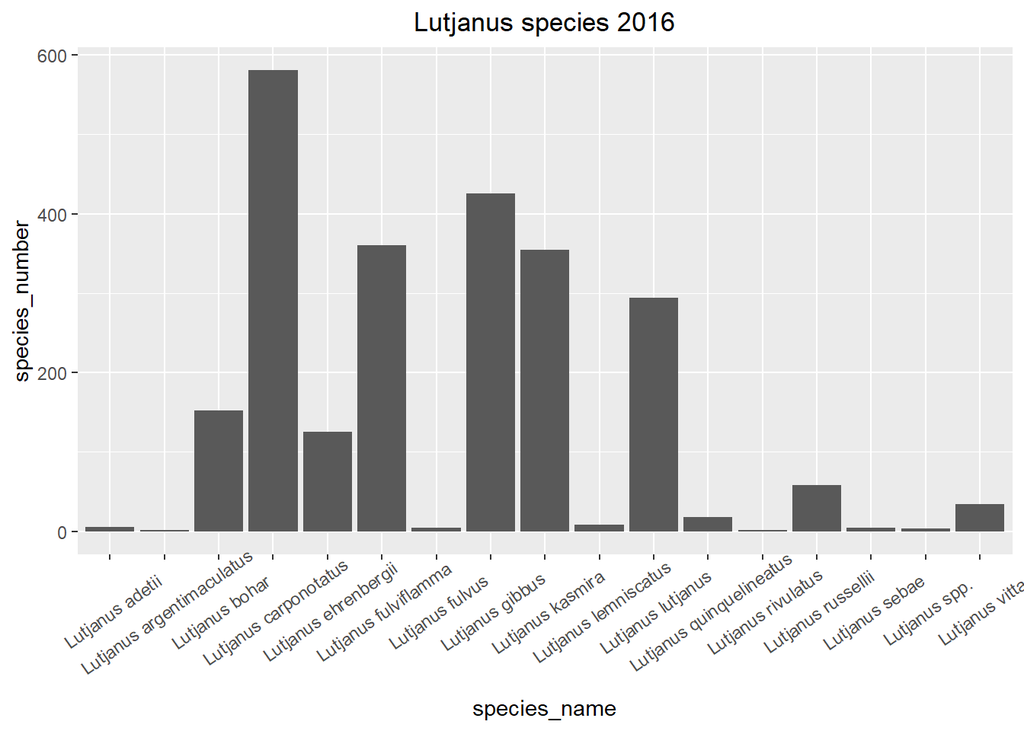

```r
#2016
Lutjanus_2016 <-as.data.table(Lutjanus_2016)
Lutjanus_2016<- Lutjanus_2016[, number := sum(total), by=species_name]
Lutjanus_2016_species <- Lutjanus_2016[, unique(number), by =c("species_name", "family")]
Lutjanus_2016_species<- dplyr::rename(Lutjanus_2016_species, species_number=V1)

ggplot(Lutjanus_2016_species, aes(x= species_name, y= species_number)) +
  geom_bar(stat = "identity")+
  ggtitle("Lutjanus species 2016")+
  ggeasy::easy_center_title()+
  theme(axis.text.x = element_text(vjust = 0.65, angle = 35))
```

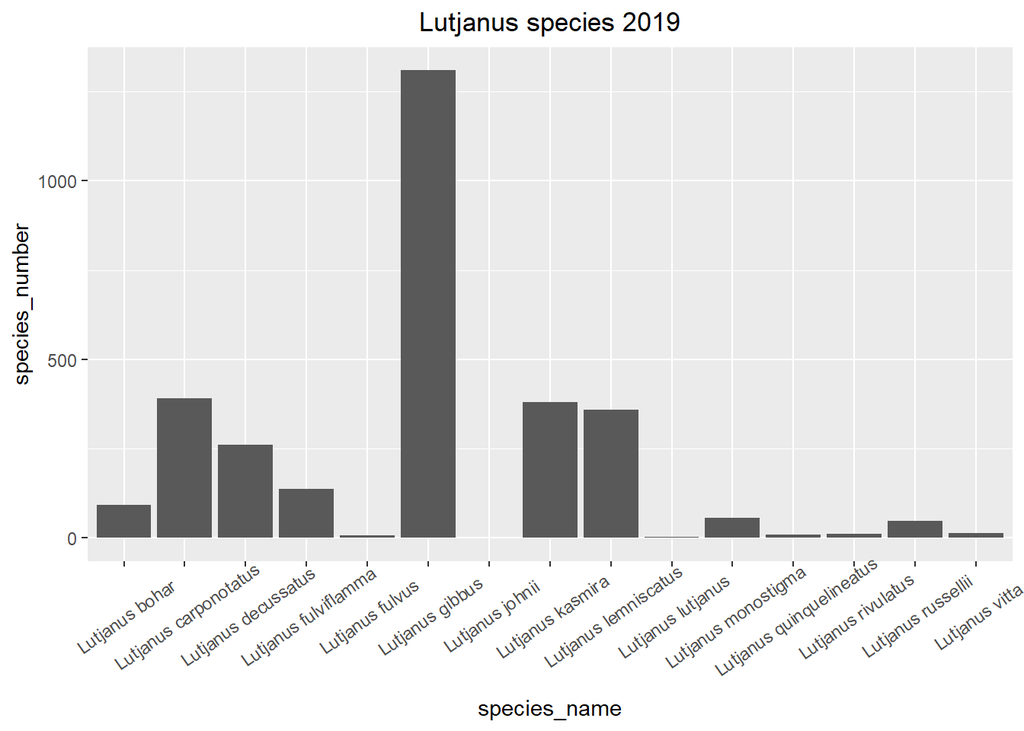

```r
#2019
Lutjanus_2019 <-as.data.table(Lutjanus_2019)
Lutjanus_2019<- Lutjanus_2019[, number := sum(total), by=species_name]
Lutjanus_2019_species <- Lutjanus_2019[, unique(number), by =c("species_name", "family")]
Lutjanus_2019_species<- dplyr::rename(Lutjanus_2019_species, species_number=V1)

ggplot(Lutjanus_2019_species, aes(x= species_name, y= species_number)) +
  geom_bar(stat = "identity")+
  ggtitle("Lutjanus species 2019")+
  ggeasy::easy_center_title()+
  theme(axis.text.x = element_text(vjust = 0.65, angle = 35))
```

Compare species between 2016 and 2019, and choose those species that were both observed in 2016 and 2019. And make a bar plot of their observation numbers.

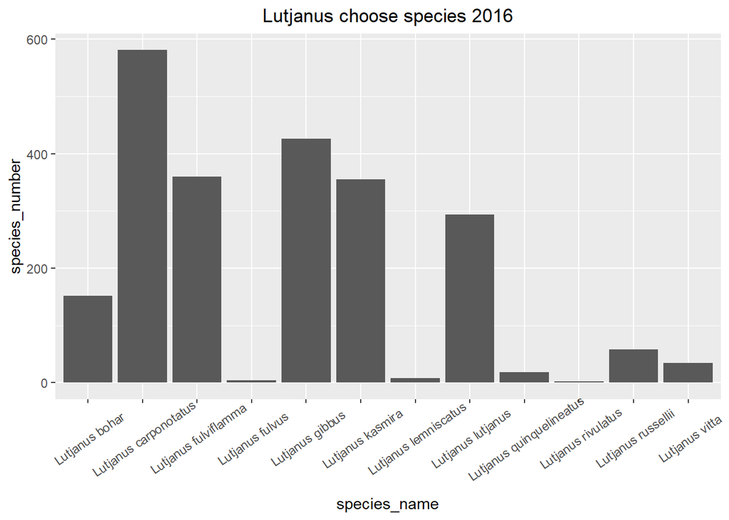

```r
#2016
Lutjanus_2016_species_12 <- Lutjanus_2016_species[-c(3,13,15,16,17),]

ggplot(Lutjanus_2016_species_12, aes(x= species_name, y= species_number)) +
  geom_bar(stat = "identity")+
  ggtitle("Lutjanus choose species 2016")+
  ggeasy::easy_center_title()+
  theme(axis.text.x = element_text(vjust = 0.65, angle = 35))
```

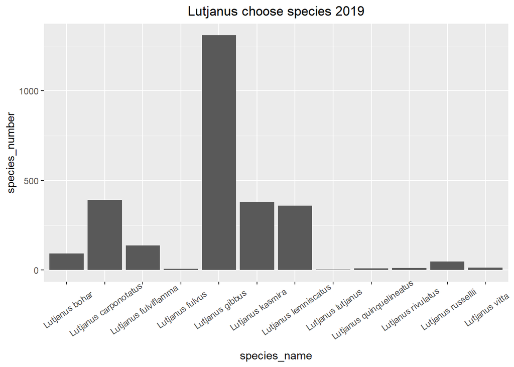

```r
Lutjanus_2016_species_12[, year:= 2016, by ="family"]


#2019
Lutjanus_2019_species_12<- Lutjanus_2019_species[-c(7,10,13),]

ggplot(Lutjanus_2019_species_12, aes(x= species_name, y= species_number)) +
  geom_bar(stat = "identity")+
  ggtitle("Lutjanus choose species 2019")+
  ggeasy::easy_center_title()+
  theme(axis.text.x = element_text(vjust = 0.65, angle = 35))
```

```r
Lutjanus_2019_species_12[, year:= 2019, by ="family"]
```

Use the observation number divided by the survey number to calculate each species’ density.

```r
Lutjanus_2019_2016 <- rbind(Lutjanus_2019_species_12, Lutjanus_2016_species_12)

#use species number/ survey number= density
Lutjanus_2019_2016[year=="2019", density:= (species_number/nrow(Lutjanus_2019))]
Lutjanus_2019_2016[year=="2016", density:= (species_number/nrow(Lutjanus_2019))]

Lutjanus_2019_2016[,log:= log(density)]

Lutjanus_2019_2016$year<- as.character(Lutjanus_2019_2016$year)
```

Use two sample t-test and Fligner-Killeen test to test if species composition are significant different between 2016 and 2019.

```r
t.test(Lutjanus_2019_2016$density~Lutjanus_2019_2016$year)
```

```
##
##  Welch Two Sample t-test
##
## data:  Lutjanus_2019_2016$density by Lutjanus_2019_2016$year
## t = -0.31717, df = 16.951, p-value = 0.755
## alternative hypothesis: true difference in means between group 2016 and group 2019 is not equal to 0
## 95 percent confidence interval:
##  -0.6959004  0.5140468
## sample estimates:
## mean in group 2016 mean in group 2019
##          0.4462617          0.5371885
```

```r
fligner.test(Lutjanus_2019_2016$density~Lutjanus_2019_2016$year)
```

```
##
##  Fligner-Killeen test of homogeneity of variances
##
## data:  Lutjanus_2019_2016$density by Lutjanus_2019_2016$year
## Fligner-Killeen:med chi-squared = 0.31652, df = 1, p-value = 0.5737
```

The density difference between 2016 to 2019 on different species in *Lutjanus*.

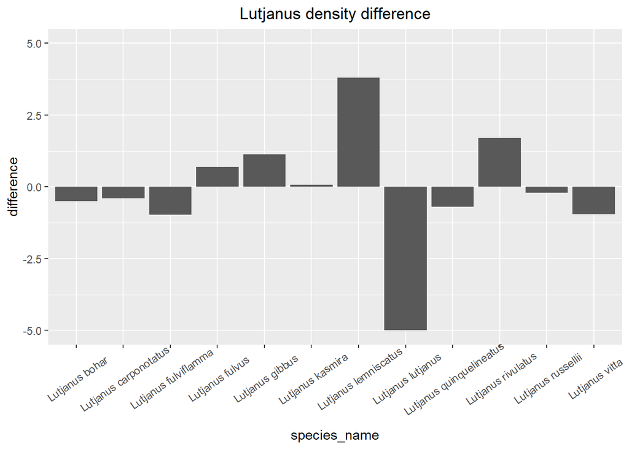

```r
Lutjanus_2019_2016_19<-Lutjanus_2019_2016[1:12,]
colnames(Lutjanus_2019_2016_19)[3:6]<-c("species_number_2019", "year_2019", "density_2019", "log_2019")
Lutjanus_2019_2016_16<-Lutjanus_2019_2016[13:24,]
colnames(Lutjanus_2019_2016_16)[3:6]<-c("species_number_2016", "year_2016", "density_2016", "log_2016")

Lutjanus_2019_2016_w_new <- merge(Lutjanus_2019_2016_19, Lutjanus_2019_2016_16)

Lutjanus_2019_2016_w_new[, difference:=(log_2019-log_2016)]

ggplot(Lutjanus_2019_2016_w_new, aes(x= species_name, y= difference)) +
  geom_bar(stat = "identity")+
  scale_y_continuous(limits = c(-5,5))+
  ggtitle("Lutjanus density difference")+
  ggeasy::easy_center_title()+
  theme(axis.text.x = element_text(vjust = 0.65, angle = 35))
```

Result & Discussion

In the Australian marine region, the density of different species in the genus *Amphiprion* showed no difference between the years 2016 and 2019 (two sample t-test p = 0.4939, Fligner-Killeen test of homogeneity p = 0.7819). While the density of different species in the genus *Lutjanus* also had no difference between 2016 and 2019 (two sample t-test p = 0.755, Fligner-Killeen test of homogeneity p = 0.5737). These results reject our hypothesis that El Niño and normal years would have differences in genus compositions.

With the unexpected result, we present several possibilities to explain it as much as possible. First, we found out that although 2016 was recorded to have the most dramatic El Niño event in recent years, it surprisingly had higher sea surface temperature (SST) in Australia compared with 2019. This fact may be evidence that the climate change impact on SST was already overtaking the El Niño event, which led to abnormal SST changes under El Niño and normal years. Therefore, when climate change disturbs the effect of El Niño, the impact on these research genera may be neutralized or intensified.

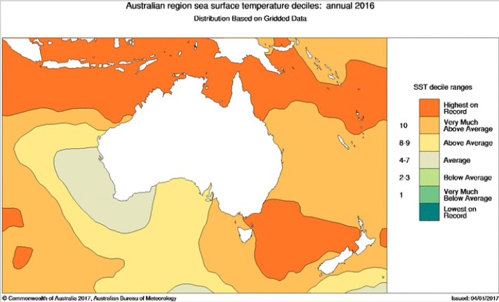

#reference: “http://www.bom.gov.au/climate/current/annual/aus/2016/#tabs=Sea-surface-temperature”

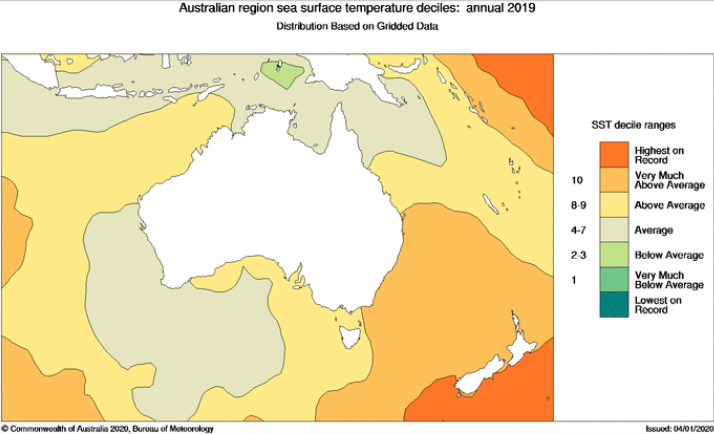

#reference: “http://www.bom.gov.au/climate/current/annual/aus/2019/#tabs=Sea-surface-temperature”

Second, to understand the impact of El Niño, we chose 2016 (El Niño year) and 2019 (relatively normal year) with enough genus and species data. However, the time between these two years may not be long enough for the composition of these genera to change. In other words, the genus composition would not change dramatically between these two years. Third, according to the dataset description, the resources of the dataset came from different collaboration memberships. One of the biggest problems was the method of recording the fish, it depended on the diving and recording skills of marine scientists and divers, and other partnerships. With non-specific members, timing, and location, could lead to various biases in fish abundance and affect the research result.

To gain a more specific understanding of the changes in genus composition, two plots illustrating changes in species density were presented. The result showed that both genera (*Amphiprion* and *Lutjanus*) did not have specific change patterns between 2016 and 2019. The possible reason is that these two genera have similar habitat preferences, which are both largely distributed in tropical and sub-tropical oceans. Therefore, they might have similar responses to environmental change, but unfortunately, there were no significant changes can be found in our research (some species’ densities increase, others decrease in both genera).

Reference  
Soman, M., Chadha, N. K., Madhu, K., Madhu, R., Sawant, P. B., & Francis, B. (2021). Optimization of temperature improves embryonic development and hatching efficiency of false clown fish, Amphiprion ocellaris Cuvier, 1830 under captive condition. Aquaculture, 536, 736417.https://doi.org/https://doi.org/10.1016/j.aquaculture.2021.736417

Velasco, G., Re, A., Diaz, F., Ibarra, L., Parra, M., Rodríguez-Ibarra, L., & Rosas, C. (2019). Thermal preference, tolerance, and thermal aerobic scope in clownfish Amphiprion ocellaris (Cuvier, 1830) predict its aquaculture potential across tropical regions. International Aquatic Research, 11.https://doi.org/10.1007/s40071-019-0228-7